# Homework 02

Author

Thomas Rodriguez

## Chapter 2

```r
library(tidyverse)
```

```r
olympics  <- read_csv('https://raw.githubusercontent.com/rfordatascience/tidytuesday/master/data/2021/2021-07-27/olympics.csv')
glimpse(olympics)
```

```
Rows: 271,116
Columns: 15
$ id     <dbl> 1, 2, 3, 4, 5, 5, 5, 5, 5, 5, 6, 6, 6, 6, 6, 6, 6, 6, 7, 7, 7, …
$ name   <chr> "A Dijiang", "A Lamusi", "Gunnar Nielsen Aaby", "Edgar Lindenau…
$ sex    <chr> "M", "M", "M", "M", "F", "F", "F", "F", "F", "F", "M", "M", "M"…
$ age    <dbl> 24, 23, 24, 34, 21, 21, 25, 25, 27, 27, 31, 31, 31, 31, 33, 33,…
$ height <dbl> 180, 170, NA, NA, 185, 185, 185, 185, 185, 185, 188, 188, 188, …
$ weight <dbl> 80, 60, NA, NA, 82, 82, 82, 82, 82, 82, 75, 75, 75, 75, 75, 75,…
$ team   <chr> "China", "China", "Denmark", "Denmark/Sweden", "Netherlands", "…
$ noc    <chr> "CHN", "CHN", "DEN", "DEN", "NED", "NED", "NED", "NED", "NED", …
$ games  <chr> "1992 Summer", "2012 Summer", "1920 Summer", "1900 Summer", "19…
$ year   <dbl> 1992, 2012, 1920, 1900, 1988, 1988, 1992, 1992, 1994, 1994, 199…
$ season <chr> "Summer", "Summer", "Summer", "Summer", "Winter", "Winter", "Wi…
$ city   <chr> "Barcelona", "London", "Antwerpen", "Paris", "Calgary", "Calgar…
$ sport  <chr> "Basketball", "Judo", "Football", "Tug-Of-War", "Speed Skating"…
$ event  <chr> "Basketball Men's Basketball", "Judo Men's Extra-Lightweight", …
$ medal  <chr> NA, NA, NA, "Gold", NA, NA, NA, NA, NA, NA, NA, NA, NA, NA, NA,…
```

```r
table(olympics$medal)
```

```
Bronze   Gold Silver
 13295  13372  13116
```

## Question 1

```r
gold_medalists <- olympics %>%
  filter(medal == "Gold")
```

There are 13,372 rows.

## Question 2

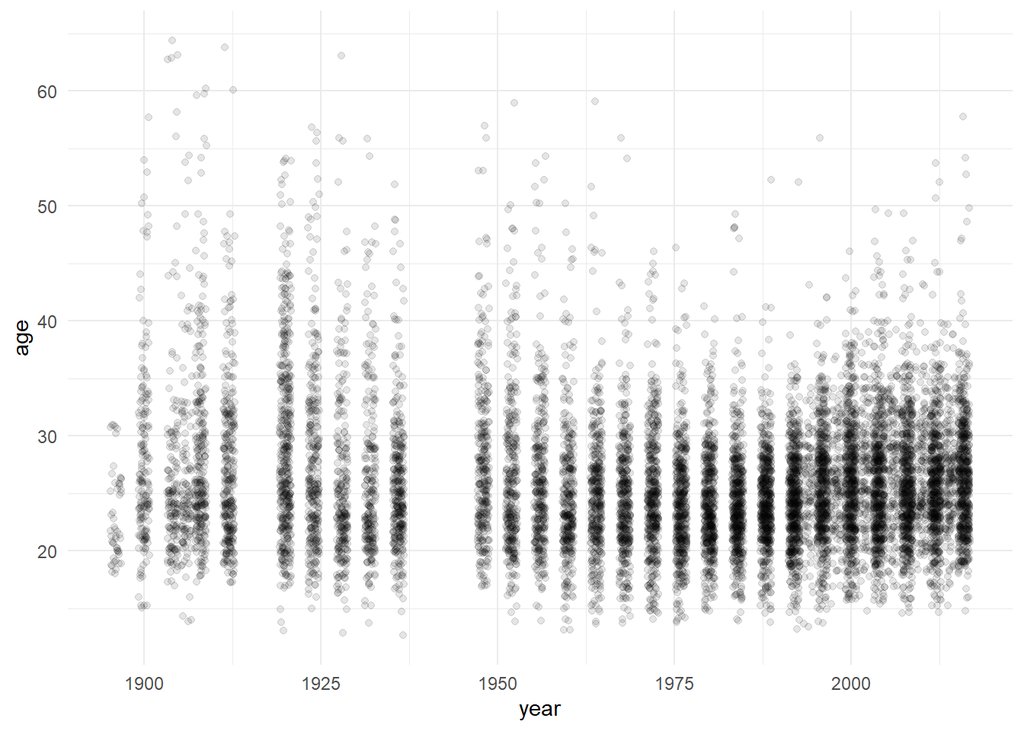

```r
ggplot(gold_medalists,
       aes(x = year,
           y = age)) +
  geom_jitter(alpha = .1) +
  theme_minimal()
```

The most appropriate plot for this data is a scatter plot because we are comparing two numerical variables.

Over the years, the age of the winners has become less varied, with most ages ranging between 18-35, and there more winners of these ages as well.

The solution to overplotting is using the alpha function to help make points more translucent and see where most of the data is gathered.

## Question 3

```r
us_medals <- gold_medalists %>%
  filter(noc == "USA") %>%
  group_by(year) %>%
  summarise(num_medals = n())
```

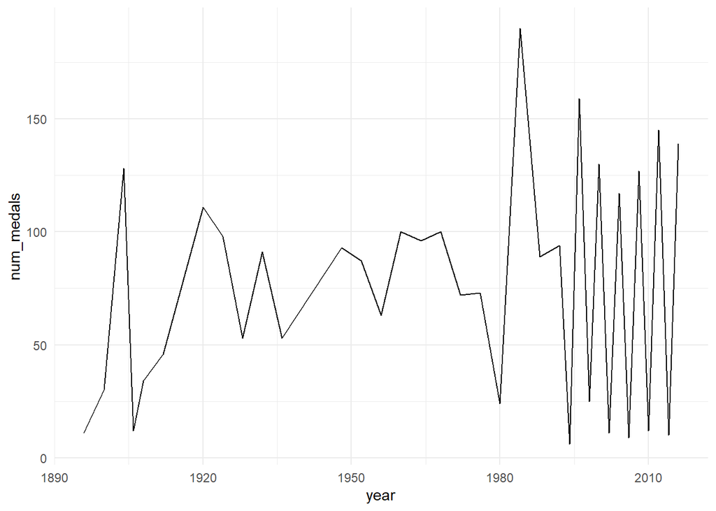

```r
ggplot(us_medals,
       aes(x = year,
           y = num_medals)) +
  geom_line() +
  theme_minimal()
```

The country’s most successful year was 1984. The line is so wiggly towards the end because the Olympics split up the Summer and Winter Olympics on different years starting in 1994, so there are more years that Olympic games are occurring than there used to be.

## Question 4

```r
two_events <- gold_medalists %>%
  filter(
    event == "Gymnastics Men's Individual All-Around"  |
      event == "Gymnastics Women's Individual All-Around" |
      event == "Athletics Women's 100 metres"   |
      event == "Athletics Men's 100 metres"
  )
```

```r
gymnastics_events <- two_events %>%
  filter(
    event == "Gymnastics Men's Individual All-Around"  |
      event == "Gymnastics Women's Individual All-Around")
```

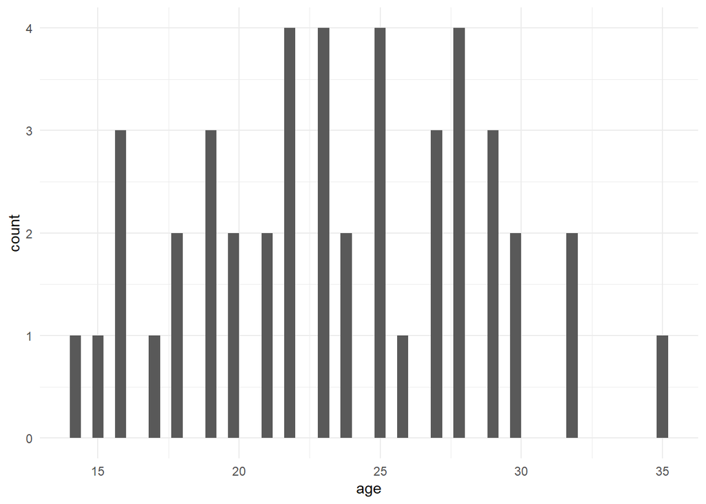

```r
ggplot(gymnastics_events,
       aes(x = age)) +
  geom_histogram(boundary = 10,
                 binwidth = .4) +
  theme_minimal()
```

Winners of the men’s and women’s individual all-around in gymnastics are likely to be between the ages of 13 and 35, but there are more winners of the mid-late teens or 20s ages.

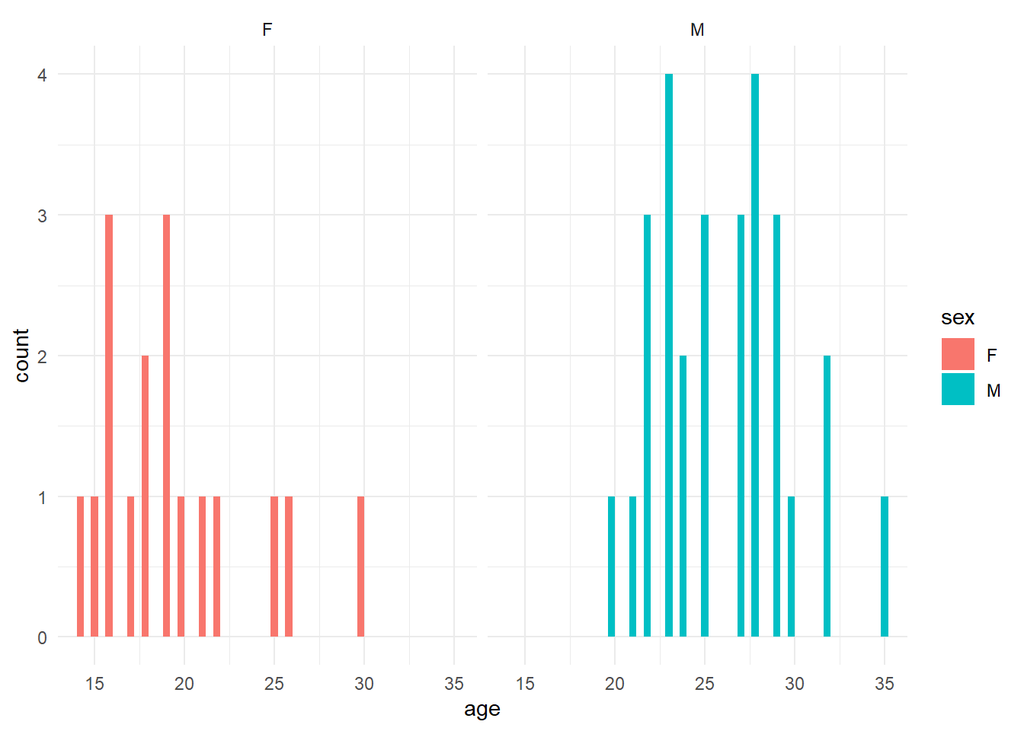

```r
ggplot(gymnastics_events,
       aes(x = age,
           group = sex,
           fill = sex)) +
  geom_histogram(boundary = 10,
                 binwidth = .4,
                 position = "dodge") +
  facet_wrap(~ sex) +
  theme_minimal()
```

Male athletes tend to be older than female athletes in gymnastics.

## Question 5

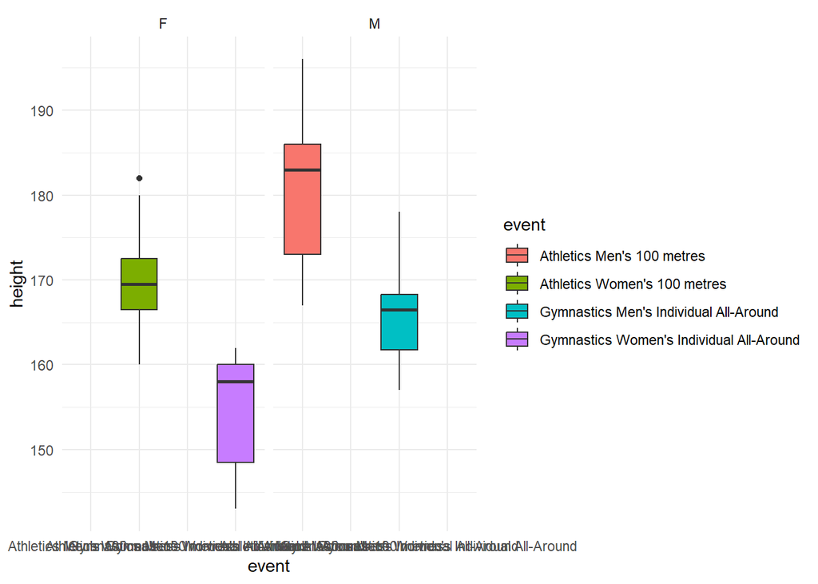

```r
ggplot(two_events,
       aes(x = event,
           y = height,
           group = event,
           fill = event)) +
  geom_boxplot() +
  facet_wrap(~ sex) +
  theme_minimal()
```

Athletes who compete in the 100 meters regardless of sex tend to be taller than those who compete in the gymnastics event. Across both events, the men tend to be taller than the women. There is a larger interquartile range of heights in the men’s 100 meters and the women’s individual all-around than there is in the women’s 100 meters and the men’s individual all-around.

## Question 6

```r
us_medalists <- gold_medalists %>%
  filter(noc == "USA")
```

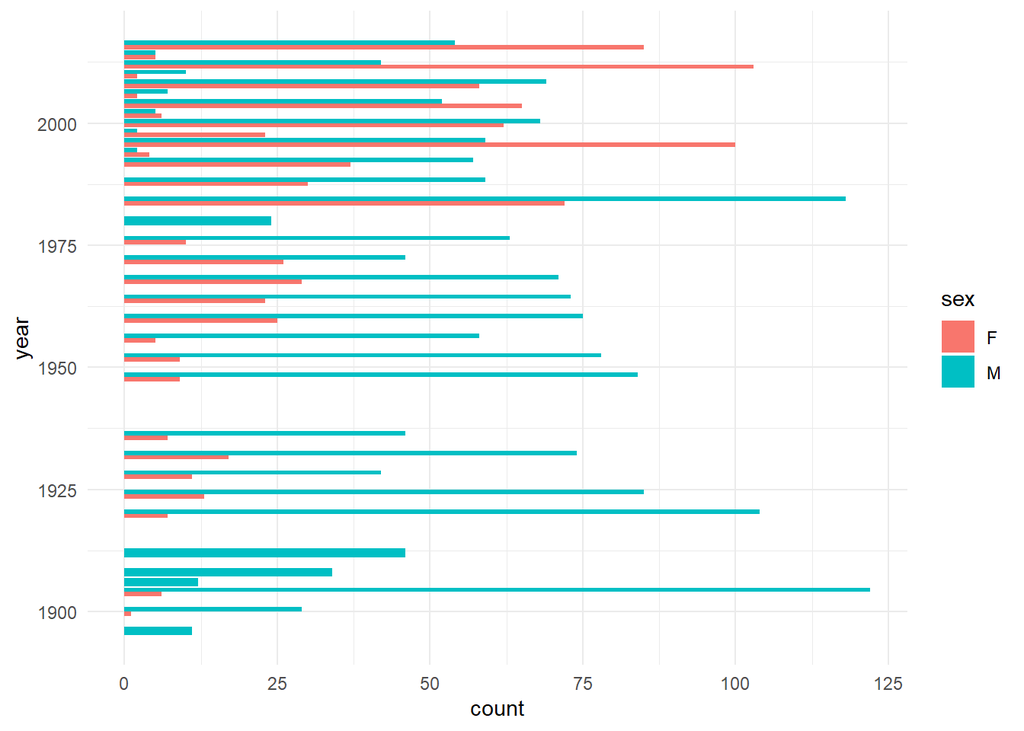

```r
ggplot(us_medalists,
       aes(y = year,
           group = sex,
           fill = sex)) +
  geom_bar(position = "dodge") +
  theme_minimal()
```

In the early and mid 1900s, male athletes were the primary winners. Around the 1980s, female athletes began to win more and more medals, even exceeding male athletes in recent years. This is most likely because more women began to pursue athletics and more Olympic events were created for women to compete in after the creation of policies and efforts that called for equality between men and women in athletics.